# Health and Migration Background in Germany - Data Analysis

Aike Myrzaibraimova

2025-05-09

# **INTRODUCTION**

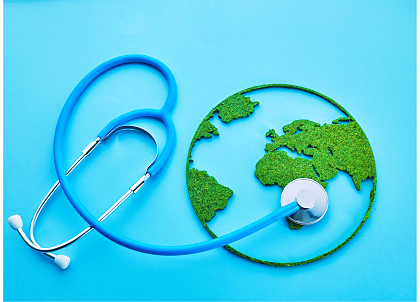

The Migration Report by the Federal Commissioner for Migration, Refugees, and Integration (2010) proposes the following definition of “migration”: “Migration is when a person relocates the center of their life. We speak of international migration when this happens across national borders. International migration to and from Germany includes immigration and emigration across the country’s borders (external migration).”[“Migrationsbericht des bundesamtes für migration und flüchtlinge im auftrag der bundesregierung (migrationsbericht 2008), year = 2010” (n.d.)

Individuals with a migration background may face higher health risks compared to the majority population without a migration background(“Migr und gesundheit (2008),” n.d.). However, it is not migration itself that leads to poorer health. Rather, it is the reasons and circumstances surrounding migration, as well as the living and working conditions of people with a migration background in Germany, that can contribute to worse health outcomes.

People with a migration background face increased risks for certain health issues that are more rare in the German population, including:

- Deaths related to childbirth and the first year of life
- Tuberculosis and other infectious diseases
- Some rare hereditary metabolic disorders

Additionally, people with a migration background are exposed to specific health risks that are not commonly experienced by Germans without a migration background, such as:

- Psychosocial stress due to separation from family
- Psychosocial stress due to xenophobia
- Political persecution or torture in their country of origin (“Migr und gesundheit (2008),” n.d.)

Nonetheless, people with a migration background are not inherently ‘sicker’ than Germans without a migration background. In fact, they often possess significant health-promoting resources. For instance, those who undertake the challenge of migration are often particularly healthy and active, exhibiting a so-called “healthy migrant effect”. The “healthy migrant” effect can create an illusion of unusually good health among immigrants. Accurately accounting for this effect in data interpretation is challenging. For instance, the lower mortality rates from heart attacks among immigrants from southern and western Mediterranean regions could be attributed to the significantly lower heart attack mortality rates in their home countries compared to Germany, rather than any selection effects related to migration(“Healthy migrant effect,” n.d.).

## Data Source

The German Socio-Economic Panel [(SOEP)](https://www.diw.de/documents/dokumentenarchiv/17/diw_01.c.604430.de/soep_flyer_2018_en.pdf) study provides extensive microdata for research in the social, economic, and behavioral sciences. Similar to a powerful telescope offering detailed views to researchers globally, SOEP serves as a crucial observatory for social phenomena. Its data support not only fundamental academic research but also social policy reports intended for a broader audience.

[SOEP-Core](http://companion.soep.de/#), the main component of the Socio-Economic Panel, is based at the German Institute for Economic Research (DIW Berlin). It began in 1984 and was notably expanded in 1990 to include East Germany’s representative sample following German reunification, a feature that distinguishes SOEP among global household panel surveys. Since 1984, SOEP’s fieldwork organization, infas Institut für angewandte Sozialwissenschaften GmbH, has surveyed individuals from participating households. The data encompasses every household member, including Germans from both former East and West Germany, foreign residents, recent immigrants, and a new sample of refugees added in 2016. Topics covered include household composition, education, occupational history, employment, earnings, health, and indicators of satisfaction.